# Project: Exploring Movie Data with Python

- Introduction
- Data Wrangling
- Exploratory Data Analysis
- Conclusions

## Introduction

Movie, also known as film, is a type of visual communication which uses moving pictures and sound to tell stories to its audience. And I am always enjoy it. In this project, I will anaylse the movie data from The Movie Database (TMDb) to explore some interesting facts.

```python
# Import library
import pandas as pd
import numpy as np
import matplotlib.pyplot as plt
from wordcloud import WordCloud
import seaborn as sns
%matplotlib inline
```

## Data Wrangling

### General Properties

```python
# Load Data
df = pd.read_csv(r'C:\Users\FORGE-15 I7\OneDrive - AsiaPay Limited\Udacity\Project 2 Investigate_Dataset\tmdb-movies.csv')
```

```python
# Dataset shape
df.shape
```

```
(10866, 21)
```

Movie dataset used in this project contains 10866 records with 21 attributes.

```python
# Dataset info
df.info()
```

```
<class 'pandas.core.frame.DataFrame'>
RangeIndex: 10866 entries, 0 to 10865
Data columns (total 21 columns):
 #   Column                Non-Null Count  Dtype
---  ------                --------------  -----
 0   id                    10866 non-null  int64
 1   imdb_id               10856 non-null  object
 2   popularity            10866 non-null  float64
 3   budget                10866 non-null  int64
 4   revenue               10866 non-null  int64
 5   original_title        10866 non-null  object
 6   cast                  10790 non-null  object
 7   homepage              2936 non-null   object
 8   director              10822 non-null  object
 9   tagline               8042 non-null   object
 10  keywords              9373 non-null   object
 11  overview              10862 non-null  object
 12  runtime               10866 non-null  int64
 13  genres                10843 non-null  object
 14  production_companies  9836 non-null   object
 15  release_date          10866 non-null  object
 16  vote_count            10866 non-null  int64
 17  vote_average          10866 non-null  float64
 18  release_year          10866 non-null  int64
 19  budget_adj            10866 non-null  float64
 20  revenue_adj           10866 non-null  float64
dtypes: float64(4), int64(6), object(11)
memory usage: 1.7+ MB
```

```python
# Descirbe dataset
df.describe()
```

|  | id | popularity | budget | revenue | runtime | vote_count | vote_average | release_year | budget_adj | revenue_adj |
| --- | --- | --- | --- | --- | --- | --- | --- | --- | --- | --- |
| count | 10866.000000 | 10866.000000 | 1.086600e+04 | 1.086600e+04 | 10866.000000 | 10866.000000 | 10866.000000 | 10866.000000 | 1.086600e+04 | 1.086600e+04 |
| mean | 66064.177434 | 0.646441 | 1.462570e+07 | 3.982332e+07 | 102.070863 | 217.389748 | 5.974922 | 2001.322658 | 1.755104e+07 | 5.136436e+07 |
| std | 92130.136561 | 1.000185 | 3.091321e+07 | 1.170035e+08 | 31.381405 | 575.619058 | 0.935142 | 12.812941 | 3.430616e+07 | 1.446325e+08 |
| min | 5.000000 | 0.000065 | 0.000000e+00 | 0.000000e+00 | 0.000000 | 10.000000 | 1.500000 | 1960.000000 | 0.000000e+00 | 0.000000e+00 |
| 25% | 10596.250000 | 0.207583 | 0.000000e+00 | 0.000000e+00 | 90.000000 | 17.000000 | 5.400000 | 1995.000000 | 0.000000e+00 | 0.000000e+00 |
| 50% | 20669.000000 | 0.383856 | 0.000000e+00 | 0.000000e+00 | 99.000000 | 38.000000 | 6.000000 | 2006.000000 | 0.000000e+00 | 0.000000e+00 |
| 75% | 75610.000000 | 0.713817 | 1.500000e+07 | 2.400000e+07 | 111.000000 | 145.750000 | 6.600000 | 2011.000000 | 2.085325e+07 | 3.369710e+07 |
| max | 417859.000000 | 32.985763 | 4.250000e+08 | 2.781506e+09 | 900.000000 | 9767.000000 | 9.200000 | 2015.000000 | 4.250000e+08 | 2.827124e+09 |

```python
# Dataset overview
df.head()
```

|  | id | imdb_id | popularity | budget | revenue | original_title | cast | homepage | director | tagline | ... | overview | runtime | genres | production_companies | release_date | vote_count | vote_average | release_year | budget_adj | revenue_adj |
| --- | --- | --- | --- | --- | --- | --- | --- | --- | --- | --- | --- | --- | --- | --- | --- | --- | --- | --- | --- | --- | --- |
| 0 | 135397 | tt0369610 | 32.985763 | 150000000 | 1513528810 | Jurassic World | Chris Pratt\|Bryce Dallas Howard\|Irrfan Khan\|Vi... | http://www.jurassicworld.com/ | Colin Trevorrow | The park is open. | ... | Twenty-two years after the events of Jurassic ... | 124 | Action\|Adventure\|Science Fiction\|Thriller | Universal Studios\|Amblin Entertainment\|Legenda... | 6/9/15 | 5562 | 6.5 | 2015 | 1.379999e+08 | 1.392446e+09 |
| 1 | 76341 | tt1392190 | 28.419936 | 150000000 | 378436354 | Mad Max: Fury Road | Tom Hardy\|Charlize Theron\|Hugh Keays-Byrne\|Nic... | http://www.madmaxmovie.com/ | George Miller | What a Lovely Day. | ... | An apocalyptic story set in the furthest reach... | 120 | Action\|Adventure\|Science Fiction\|Thriller | Village Roadshow Pictures\|Kennedy Miller Produ... | 5/13/15 | 6185 | 7.1 | 2015 | 1.379999e+08 | 3.481613e+08 |
| 2 | 262500 | tt2908446 | 13.112507 | 110000000 | 295238201 | Insurgent | Shailene Woodley\|Theo James\|Kate Winslet\|Ansel... | http://www.thedivergentseries.movie/#insurgent | Robert Schwentke | One Choice Can Destroy You | ... | Beatrice Prior must confront her inner demons ... | 119 | Adventure\|Science Fiction\|Thriller | Summit Entertainment\|Mandeville Films\|Red Wago... | 3/18/15 | 2480 | 6.3 | 2015 | 1.012000e+08 | 2.716190e+08 |
| 3 | 140607 | tt2488496 | 11.173104 | 200000000 | 2068178225 | Star Wars: The Force Awakens | Harrison Ford\|Mark Hamill\|Carrie Fisher\|Adam D... | http://www.starwars.com/films/star-wars-episod... | J.J. Abrams | Every generation has a story. | ... | Thirty years after defeating the Galactic Empi... | 136 | Action\|Adventure\|Science Fiction\|Fantasy | Lucasfilm\|Truenorth Productions\|Bad Robot | 12/15/15 | 5292 | 7.5 | 2015 | 1.839999e+08 | 1.902723e+09 |
| 4 | 168259 | tt2820852 | 9.335014 | 190000000 | 1506249360 | Furious 7 | Vin Diesel\|Paul Walker\|Jason Statham\|Michelle ... | http://www.furious7.com/ | James Wan | Vengeance Hits Home | ... | Deckard Shaw seeks revenge against Dominic Tor... | 137 | Action\|Crime\|Thriller | Universal Pictures\|Original Film\|Media Rights ... | 4/1/15 | 2947 | 7.3 | 2015 | 1.747999e+08 | 1.385749e+09 |

5 rows × 21 columns

After go through data, several attributes need to be cleaned to improve data quality.

Pre-processing steps to do:

- Drop unused attributes/features
- Fix missing values
- Drop duplicated rows
- Fix columns datatype
- Change scientific notation values in budget and revenue columns
- Fix zero value

```python
# Drop Column
df.drop(['id', 'imdb_id', 'budget', 'revenue', 'homepage', 'tagline', 'keywords', 'overview'], axis=1, inplace=True)
```

```python
# Check columns left in dataset
for c in df.columns:
    print(c)
```

```
popularity
original_title
cast
director
runtime
genres
production_companies
release_date
vote_count
vote_average
release_year
budget_adj
revenue_adj
```

```python
# Check missing value in each column
df.isnull().sum()
```

```
popularity                 0
original_title             0
cast                      76
director                  44
runtime                    0
genres                    23
production_companies    1030
release_date               0
vote_count                 0
vote_average               0
release_year               0
budget_adj                 0
revenue_adj                0
dtype: int64
```

There are missing values in cast, director, genres, and production_companies columns. The datatype of these columns are string where missing values cannot be replaced by numeric values like mean and mode. Thus, I am going to replace all missing value with 'Unknown'.

```python
# Fill missing value with 'Unknown'
col = ['cast', 'director', 'genres', 'production_companies']
for c in col:
    df[c].fillna('Unknown', inplace=True)
```

```python
# Check missing value again
df.isnull().sum()
```

```
popularity              0
original_title          0
cast                    0
director                0
runtime                 0
genres                  0
production_companies    0
release_date            0
vote_count              0
vote_average            0
release_year            0
budget_adj              0
revenue_adj             0
dtype: int64
```

After fixing missing values, I will drop duplicated row(s) from dataset since it is redundant.

```python
# Check duplicated row
df.duplicated().sum()
```

```
1
```

```python
# Drop duplicated row
df.drop_duplicates(inplace=True)
```

```python
# Check duplicated again
df.duplicated().sum()
```

```
0
```

From the dataset info above, release_date should be convert to datetime format for better manipulation later.

```python
# Convert to datetime format
df['release_date'] = pd.to_datetime(df['release_date'])
```

```python
# Check datatype again
df.info()
```

```
<class 'pandas.core.frame.DataFrame'>
Int64Index: 10865 entries, 0 to 10865
Data columns (total 13 columns):
 #   Column                Non-Null Count  Dtype
---  ------                --------------  -----
 0   popularity            10865 non-null  float64
 1   original_title        10865 non-null  object
 2   cast                  10865 non-null  object
 3   director              10865 non-null  object
 4   runtime               10865 non-null  int64
 5   genres                10865 non-null  object
 6   production_companies  10865 non-null  object
 7   release_date          10865 non-null  datetime64[ns]
 8   vote_count            10865 non-null  int64
 9   vote_average          10865 non-null  float64
 10  release_year          10865 non-null  int64
 11  budget_adj            10865 non-null  float64
 12  revenue_adj           10865 non-null  float64
dtypes: datetime64[ns](1), float64(4), int64(3), object(5)
memory usage: 1.2+ MB
```

Values in both budget_adj and revenue_adj are displayed in scientic notation format. I will convert the values to million with 2 decimal places.

```python
# Convert scientific notation to million with 2 decimal places
col = ['budget_adj', 'revenue_adj']
for c in col:
    df[c] =  df[c].apply(lambda x: x/1000000) # convert to million
    df[c] =  df[c].apply(lambda x: '{:.2f}'.format(x)) # 2 decimal places
    df[c] =  df[c].astype(float) # convert to float again
```

```python
# Check values
#df[['budget_adj', 'revenue_adj']]
#df.iloc[:,[-1,-2]]
df.loc[:, ['budget_adj', 'revenue_adj']]
```

|  | budget_adj | revenue_adj |
| --- | --- | --- |
| 0 | 138.00 | 1392.45 |
| 1 | 138.00 | 348.16 |
| 2 | 101.20 | 271.62 |
| 3 | 184.00 | 1902.72 |
| 4 | 174.80 | 1385.75 |
| ... | ... | ... |
| 10861 | 0.00 | 0.00 |
| 10862 | 0.00 | 0.00 |
| 10863 | 0.00 | 0.00 |
| 10864 | 0.00 | 0.00 |
| 10865 | 0.13 | 0.00 |

10865 rows × 2 columns

I also found that there are movies with zero runtime, budget_adj, revenue_adj. This happens because the datatype is int/float where when no value is given for the column, it will be set to its default value, zero. I will assign mean to these values.

```python
# Replace the zero value with mean
col = ['runtime', 'budget_adj', 'revenue_adj']
for c in col:
    df[c] = df[c].replace(0, df[c].mean())
```

```python
# Check min again
df[['runtime', 'budget_adj', 'revenue_adj']].describe()
```

|  | runtime | budget_adj | revenue_adj |
| --- | --- | --- | --- |
| count | 10865.000000 | 10865.000000 | 10865.000000 |
| mean | 102.363021 | 26.849040 | 80.143190 |
| std | 30.904043 | 30.451774 | 136.433006 |
| min | 2.000000 | 0.010000 | 0.010000 |
| 25% | 90.000000 | 17.549923 | 51.368990 |
| 50% | 99.000000 | 17.549923 | 51.368990 |
| 75% | 111.000000 | 20.850000 | 51.368990 |
| max | 900.000000 | 425.000000 | 2827.120000 |

## Exploratory Data Analysis

#### Q1. What is the trend of number of movie released from 1960 to 2015?

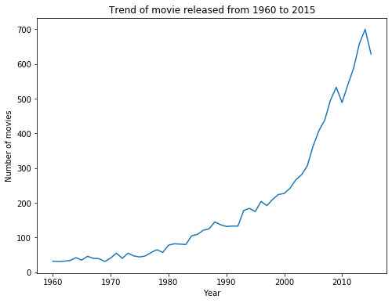

```python
# Plot line graph to show trend
plt.figure(figsize = (8, 6))
df.groupby('release_year')['original_title'].count().plot()
plt.title("Trend of movie released from 1960 to 2015")
plt.xlabel("Year")
plt.ylabel("Number of movies");
```

#### Q2. What is the distribution of movie runtime?

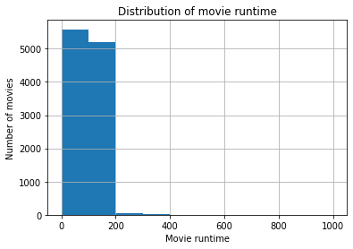

```python
# Plot histogram to show distribution of movie runtime
df['runtime'].hist(range=[0, 1000], bins=10)
plt.title("Distribution of movie runtime")
plt.xlabel("Movie runtime")
plt.ylabel("Number of movies");
```

#### Q3. What is the highest profit a movie earned?

*Profit = Revenue - Budget*

```python
# Create profit column
df['profit'] = df['revenue_adj'] - df['budget_adj']
```

```python
# Select the movie with top earning
df[df['profit'] == df['profit'].max()].loc[:,['original_title', 'profit']]
```

|  | original_title | profit |
| --- | --- | --- |
| 1329 | Star Wars | 2750.13 |

Wow, Star Wars has the top earning with 2750 millions.

#### Q4. What is the top 10 movies with highest profit and loss?

```python
# Sort the dataframe order by profit
#df_sort_profit = df.sort_values('profit', ascending=False).reset_index()
df_sort_profit = df.sort_values('profit', ascending=False, ignore_index=True) #ignore_index is added after pandas_v1.0
```

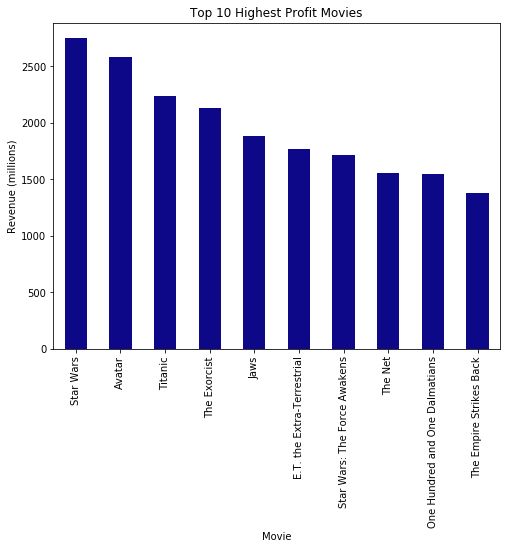

```python
# Plot highest profit
labels = highest_10_profit['original_title'].tolist()

plt.figure(figsize = (8, 6))
highest_10_profit['profit'].plot(kind='bar', cmap="plasma")
plt.title("Top 10 Highest Profit Movies")
plt.xlabel("Movie")
plt.ylabel("Revenue (millions)");
plt.xticks(range(len(labels)), labels);
```

We can convert the negative profit value to indicate the loss.

[figure not shown]

```python
# Plot highest loss
lowest_10_profit = df_sort_profit.tail(10)
lowest_10_profit = lowest_10_profit.sort_values('profit', ascending=True, ignore_index=False)
loss = abs(lowest_10_profit['profit'])
labels = lowest_10_profit['original_title'].tolist()

plt.figure(figsize = (8, 6))
loss.plot(kind='bar', color="r")
plt.title("Top 10 Highest Loss Movies")
plt.xlabel("Movie")
plt.ylabel("Revenue (millions)");
plt.xticks(range(len(labels)), labels);
```

#### Q5. Is that movies with higher budget will make the profit higher too?

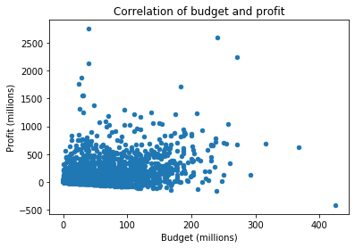

```python
# Scatterplot to show correlation between budget_adj and revenue_adj
df.plot(x='budget_adj', y='profit', kind='scatter')
plt.title("Correlation of budget and profit")
plt.xlabel("Budget (millions)")
plt.ylabel("Profit (millions)");
```

#### Q6. What is the number of movies in each category?

```python
# Define function to get all occurance in a column with values split with "|"
def getOccurances(column):
    listOcc = []
    for i in df[column]:
        split = list(map(str, i.split('|')))
        for j in split:
            if j not in listOcc:
                listOcc.append(j)
    return listOcc
```

```python
# Define function to count for each word in occurance list
def getOccurancesCount(occurancesList, column):
    count = 0
    word_count = dict()
    for i in occurancesList:
        for x in df[column]:
            if i in x.split('|'):
                count+=1;
        word_count[i] = count
        count = 0
    return {k: v for k, v in sorted(word_count.items(), key=lambda x: x[1],reverse=True)}
```

```python
# Get all the genres of movies in dataset.
genresList = getOccurances('genres')
print("There are total " + str(len(genresList)) +  " of genres in dataset.")
print(genresList)
```

```
There are total 21 of genres in dataset.
['Action', 'Adventure', 'Science Fiction', 'Thriller', 'Fantasy', 'Crime', 'Western', 'Drama', 'Family', 'Animation', 'Comedy', 'Mystery', 'Romance', 'War', 'History', 'Music', 'Horror', 'Documentary', 'TV Movie', 'Unknown', 'Foreign']
```

```python
# Get number of movies for each genres
genresCount = getOccurancesCount(genresList, 'genres')
genresCount
```

```
{'Drama': 4760,
 'Comedy': 3793,
 'Thriller': 2907,
 'Action': 2384,
 'Romance': 1712,
 'Horror': 1637,
 'Adventure': 1471,
 'Crime': 1354,
 'Family': 1231,
 'Science Fiction': 1229,
 'Fantasy': 916,
 'Mystery': 810,
 'Animation': 699,
 'Documentary': 520,
 'Music': 408,
 'History': 334,
 'War': 270,
 'Foreign': 188,
 'TV Movie': 167,
 'Western': 165,
 'Unknown': 23}
```

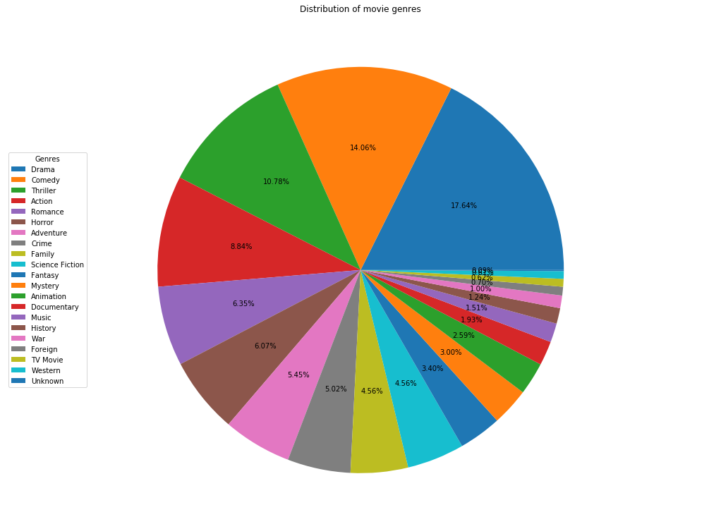

```python
# Plot piechart
fig = plt.figure(figsize = (14, 10))
ax = fig.add_axes([0,0,1,1])
ax.axis('equal')
genre = genresCount.keys()
num = genresCount.values()
ax.pie(num, autopct='%1.2f%%') #ax.pie(num, labels = genre, autopct='%1.2f%%')
ax.legend(genre,
          title="Genres",
          loc="center left")
plt.title('Distribution of movie genres')
plt.show();
```

#### Q7. Which actor involved most in the movies?

```python
# Get number of mmovies involved for each actor
castCount = getOccurancesCount(getOccurances('cast'), 'cast')
castCount
```

[output not shown]

[output cut: 946 more lines]

```
 'Jennifer Coolidge': 10,
 'George Lopez': 10,
 'Rainn Wilson': 10,
 'Kal Penn': 10,
 'Casper Van Dien': 10,
 'Luke Goss': 10,
 'Donal Logue': 10,
 'Mark Webber': 10,
 'Connie Nielsen': 10,
 'Sarah Silverman': 10,
 'Candice Bergen': 10,
 'Jamie Kennedy': 10,
 'Alan Tudyk': 10,
 'Tara Reid': 10,
 ...}
```

```python
# Define function to plot word cloud
def makeCloud(dict,name,color):

    wordcloud = WordCloud(
                  width=1500,
                  height=750,
                  background_color=color,
                  max_words=50,
                  max_font_size=500,
                  normalize_plurals=False)
    wordcloud.generate_from_frequencies(dict)

    fig = plt.figure(figsize=(12, 8))
    plt.title(name)
    plt.imshow(wordcloud)
    plt.axis('off')

    plt.show()
```

The first row of the castCount dictionary ('Unknown') should be ignored.

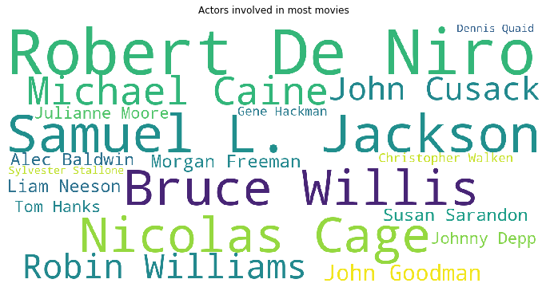

```python
# Plot word cloud
makeCloud({i: castCount[i] for i in list(castCount)[1:20]},"Actors involved in most movies","White")
```

## Conclusions

#### Limitations/ Future Works

In this project, there is several columns dropped like keyword. This attribute is actually a important source to build a movie recommendation system. Furthermore, there is the data analysis could be done in a more detail where analysis on movie genres level.

For future references:

- https://www.kaggle.com/lorenzhering/movie-data-analysis
- https://pandas.pydata.org/pandas-docs/stable/reference/api/pandas.Series.explode.html